# Trends in Student Number over time by Gunagwera Alex

```r
# Load all of the packages that you end up using
# in your analysis in this code chunk.

# Notice that the parameter "echo" was set to FALSE for this code chunk.
# This prevents the code from displaying in the knitted HTML output.
# You should set echo=FALSE for all code chunks in your file.

library(ggplot2)
```

# Univariate Plots Section

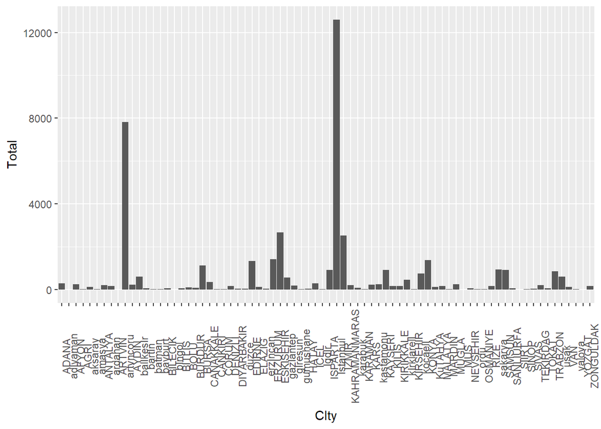

```r
par(cex=1.5)
f1314Totaless = subset(foreign1314, (Total < 10000))
f1415Totaless = subset(foreign1415, (Total < 15000))
f1516Totaless = subset(foreign1516, (Total < 20000))
f1617Totaless = subset(foreign1617, (Total < 20000))

ggplot(aes(CIty, Total), data = f1314Totaless) +
  geom_histogram(stat = 'identity') +
  theme(axis.text.x = element_text(angle = 90))
```

# Univariate Plots Section

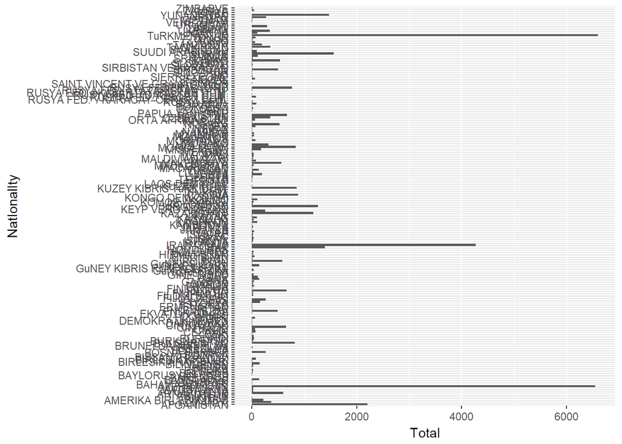

```r
ggplot(aes(NatIonalIty, Total), data = f1314Totaless) +
  geom_histogram(stat = 'identity') +
  coord_flip()
```

## Foreign Students Vs University Type

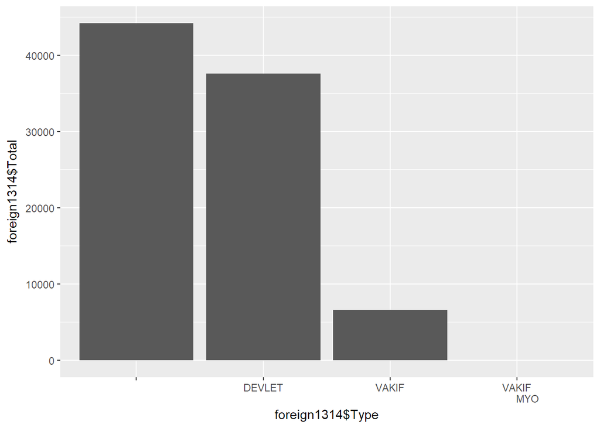

```r
ggplot(aes(foreign1314$Type, foreign1314$Total), data = subset(foreign1314, !is.na(foreign1314$Type))) +
  geom_histogram(stat = 'identity')
```

# Univariate Plots Section

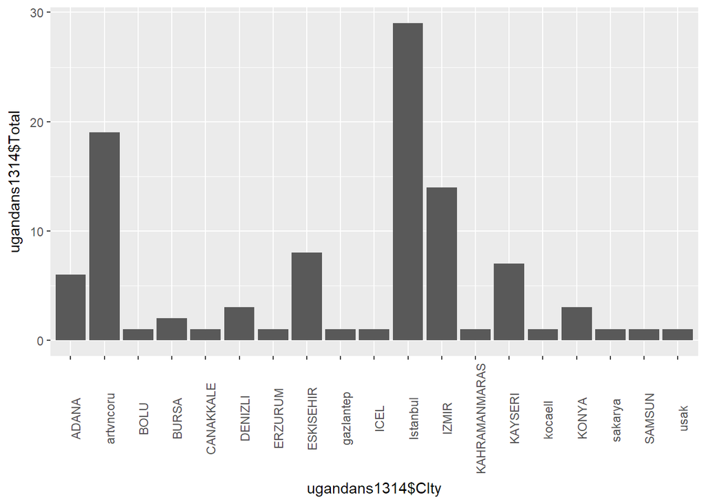

```r
ugandans1314 = subset(foreign1314, foreign1314$NatIonalIty=="UGANDA")
ugandans1415 = subset(foreign1415, foreign1415$NatIonalIty=="UGANDA")
ugandans1516 = subset(foreign1516, foreign1516$NatIonalIty=="UGANDA ")
ugandans1617 = subset(foreign1617, foreign1617$NatIonalIty=="UGANDA ")
iran1617 = subset(foreign1617, foreign1617$NatIonalIty=="ARNAVUTLUK ")
iran1314 = subset(foreign1314, foreign1314$NatIonalIty=="ARNAVUTLUK")
ggplot(aes(ugandans1314$CIty, ugandans1314$Total), data = ugandans1314) +
  geom_histogram(stat = 'identity') +
  theme(axis.text.x = element_text(angle = 90))
```

```r
head(iran1617, 10)
```

```
##           UnIversIty   Type      CIty NatIonalIty Male Female Total
## 4    abantIzetbaysal DEVLET      BOLU ARNAVUTLUK     1      5     6
## 67         abdlahgul DEVLET   KAYSERI ARNAVUTLUK     1      0     1
## 122    adnanmenderes DEVLET     AYDIN ARNAVUTLUK     7      0     7
## 278         akdenIz  DEVLET   ANTALYA ARNAVUTLUK     0      4     4
## 409         aksaray  DEVLET   ANTALYA ARNAVUTLUK     1      0     1
## 485         anadolu  DEVLET ESKISEHIR ARNAVUTLUK    29     27    56
## 647       artvncoru  DEVLET artvncoru ARNAVUTLUK     7     21    28
## 776  artvncoruyldrm  DEVLET artvncoru ARNAVUTLUK    10      9    19
## 966          atIlIm   VAKIF artvncoru ARNAVUTLUK     0      1     1
## 1039     bahcesehIr   VAKIF  Istanbul ARNAVUTLUK     5      3     8
```

## Ugandans’ distribution in 2013-2014

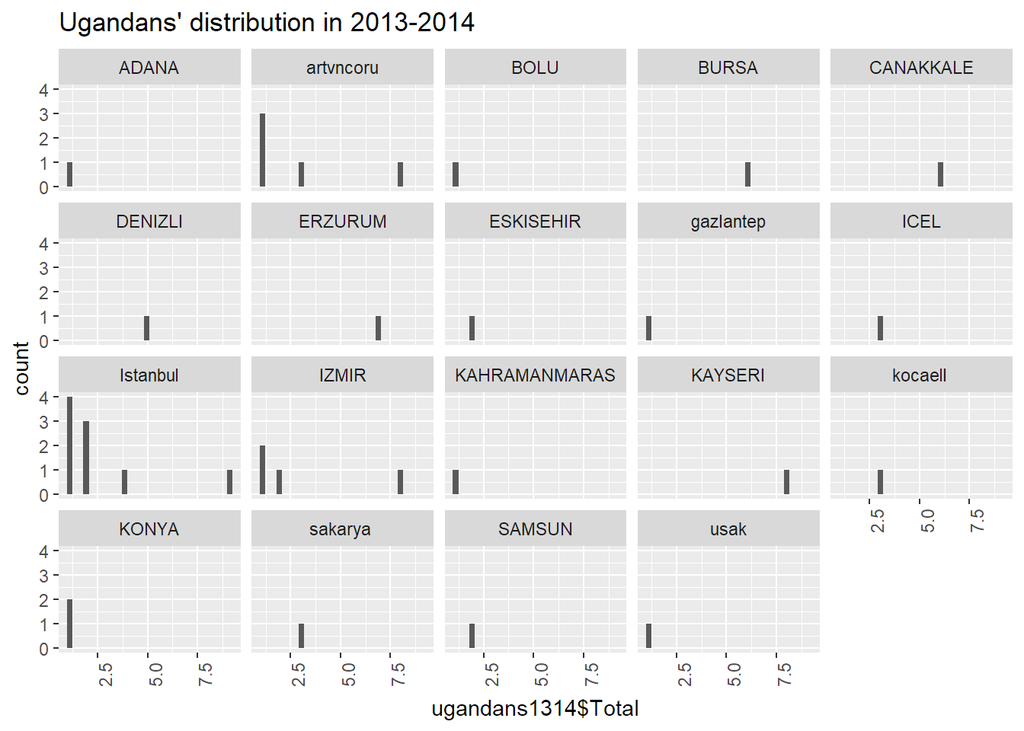

```r
ggplot(aes(x = ugandans1314$Total), data = ugandans1314) +
  geom_histogram() +
  scale_x_continuous() +
  facet_wrap(~ugandans1314$CIty)+
  theme(axis.text.x = element_text(angle = 90)) +
  ggtitle("Ugandans' distribution in 2013-2014")
```

## Universities They Joined

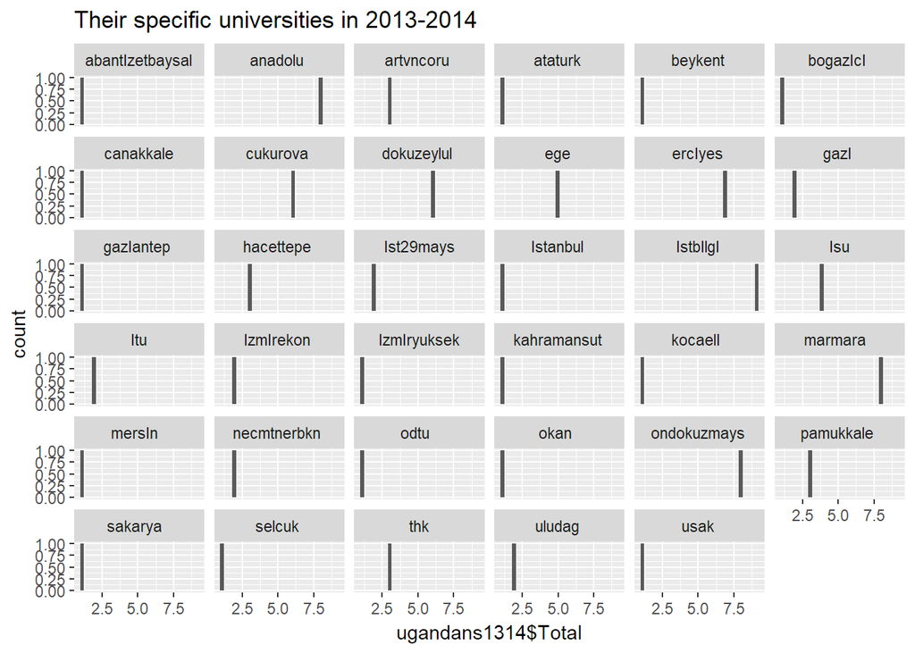

```r
ggplot(aes(x = ugandans1314$Total), data = ugandans1314) +
  geom_histogram() +
  scale_x_continuous() +
  facet_wrap(~ugandans1314$UnIversIty) +
  ggtitle("Their specific universities in 2013-2014")
```

### For the year 2014-2015

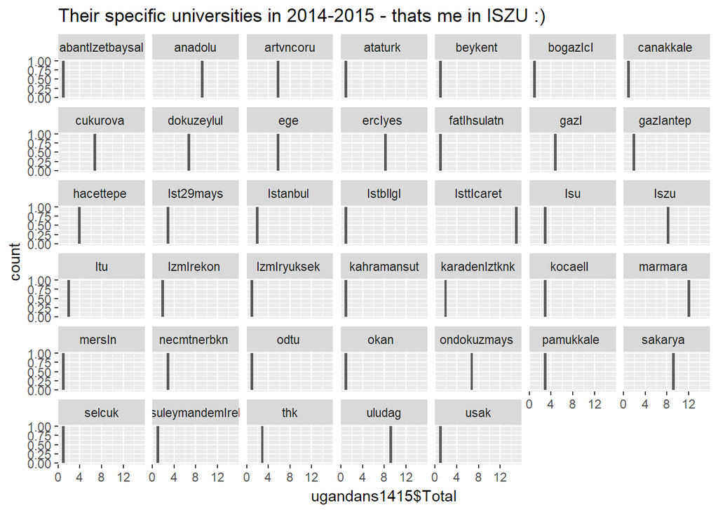

```r
ggplot(aes(x = ugandans1415$Total), data = ugandans1415) +
  geom_histogram() +
  scale_x_continuous() +
  facet_wrap(~ugandans1415$UnIversIty)+
  ggtitle("Their specific universities in 2014-2015 - thats me in ISZU :)")
```

### Their universities in 2016-2017

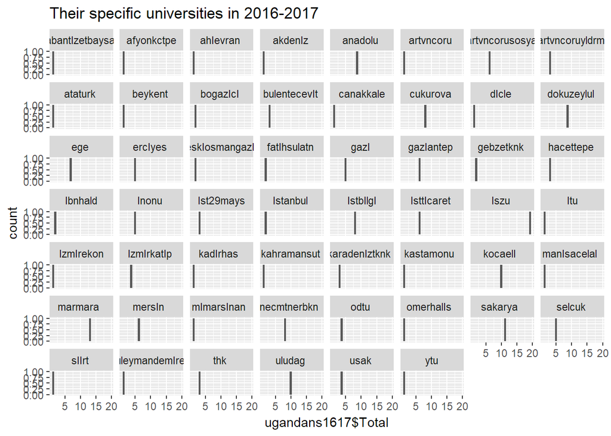

```r
ggplot(aes(x = ugandans1617$Total), data = ugandans1617) +
  geom_histogram() +
  facet_wrap(~ugandans1617$UnIversIty)+
  ggtitle("Their specific universities in 2016-2017")
```

## Boxplot on the City and Total Foreigners Year: 2013 - 2014

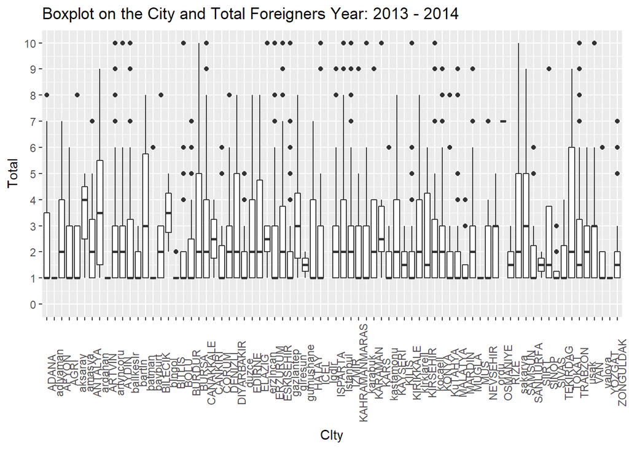

```r
qplot(x = CIty , y = Total , data = f1314Totaless,
  geom = 'boxplot' , main = 'Boxplot on the City and Total Foreigners Year: 2013 - 2014')+
  scale_y_continuous(limits = c(0,10),breaks = seq(0,15,1))+
  theme(axis.text.x = element_text(angle = 90))
```

## Boxplot on the City and Total Ugandans : 2013 - 2014

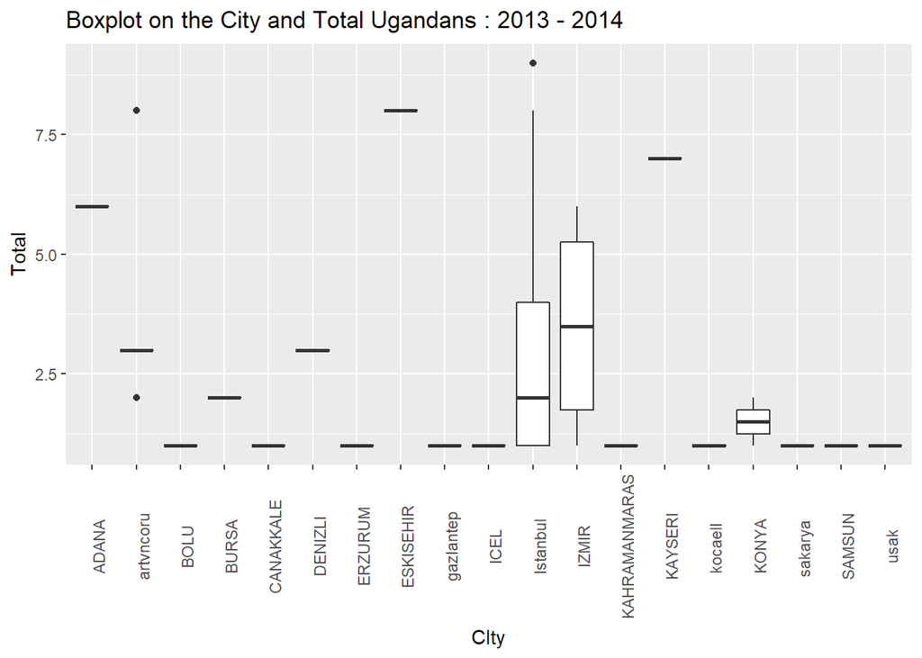

```r
qplot(x = CIty , y = Total , data = ugandans1314,
  geom = 'boxplot' , main = 'Boxplot on the City and Total Ugandans : 2013 - 2014')+
  scale_y_continuous()+
  theme(axis.text.x = element_text(angle = 90))
```

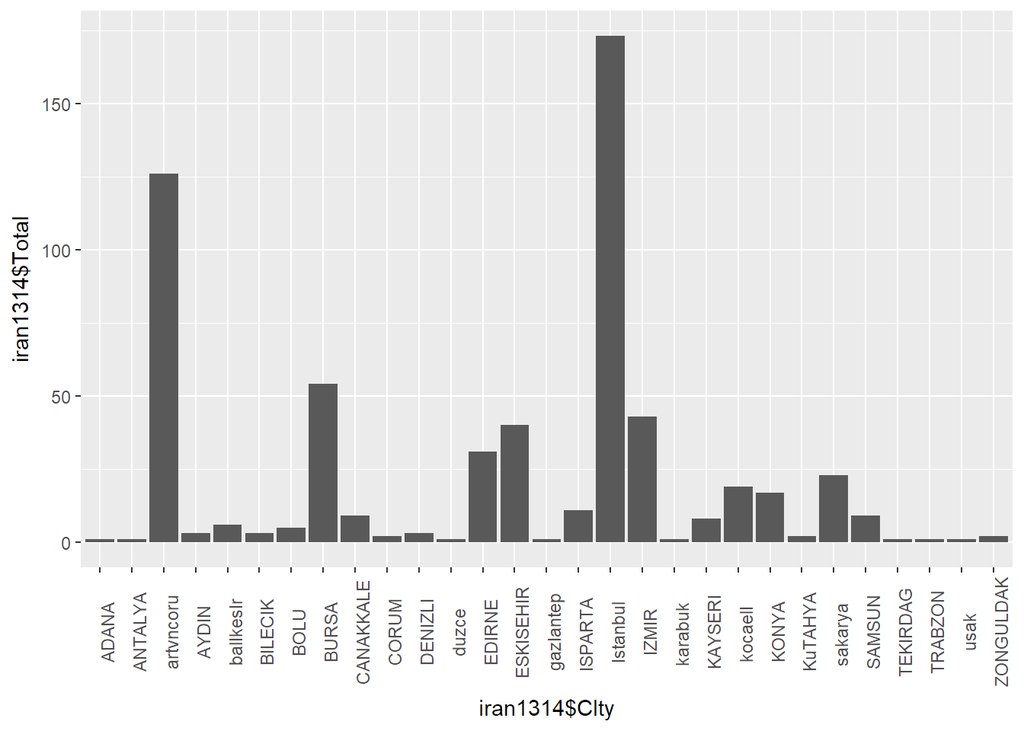

```r
ggplot(aes(iran1314$CIty, iran1314$Total), data = iran1314) +
  geom_histogram(stat = 'identity') +
  theme(axis.text.x = element_text(angle = 90))
```

```r
head(iran1314, 10)
```

```
##          UnIversIty   Type      CIty NatIonalIty Male Female Total
## 2   abantIzetbaysal DEVLET      BOLU  ARNAVUTLUK    2      3     5
## 46    adnanmenderes DEVLET     AYDIN  ARNAVUTLUK    2      1     3
## 130        akdenIz  DEVLET   ANTALYA  ARNAVUTLUK    0      1     1
## 169        anadolu  DEVLET ESKISEHIR  ARNAVUTLUK   21     13    34
## 255      artvncoru  DEVLET artvncoru  ARNAVUTLUK   10     17    27
## 450     bahcesehIr   VAKIF  Istanbul  ARNAVUTLUK    2      4     6
## 519      balIkesIr  DEVLET balIkesIr  ARNAVUTLUK    4      2     6
## 600        beykent   VAKIF  Istanbul  ARNAVUTLUK    1      2     3
## 649     bIlecIkseyh DEVLET   BILECIK  ARNAVUTLUK    2      1     3
## 677       bogazIcI  DEVLET  Istanbul  ARNAVUTLUK    0      6     6
```

### Boxplot on the City and Total Foreigners Year: 2014-2015

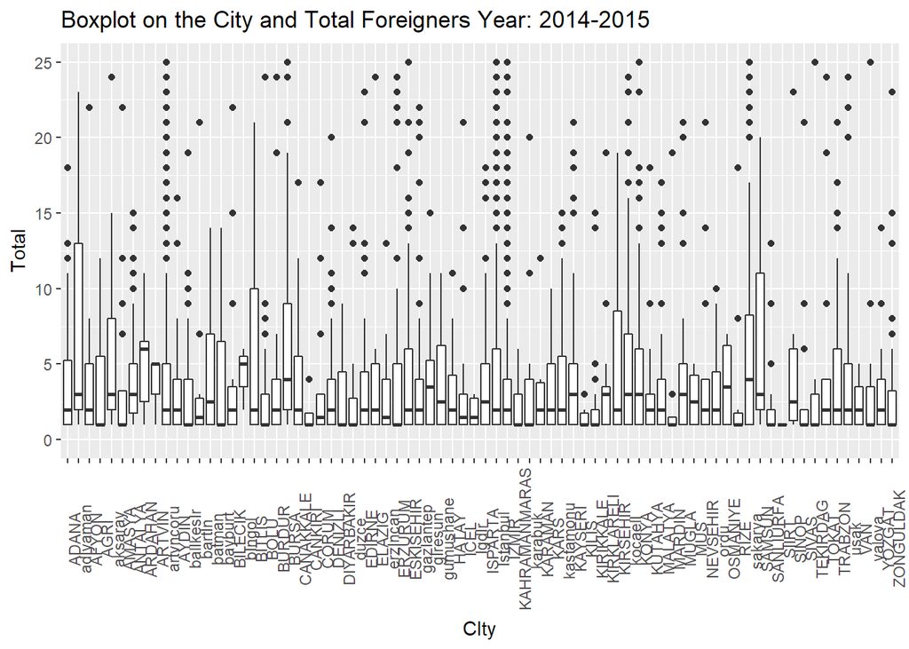

```r
qplot(x = CIty , y = Total , data = f1415Totaless,
  geom = 'boxplot' , main = 'Boxplot on the City and Total Foreigners Year: 2014-2015')+
  scale_y_continuous(limits = c(0,25))+
  theme(axis.text.x = element_text(angle = 90))
```

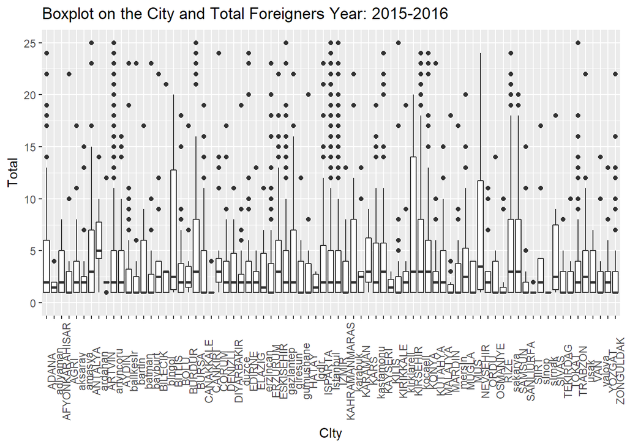

```r
qplot(x = CIty , y = Total , data = f1516Totaless,
  geom = 'boxplot' , main = 'Boxplot on the City and Total Foreigners Year: 2015-2016')+
  scale_y_continuous(limits = c(0,25))+
  theme(axis.text.x = element_text(angle = 90))
```

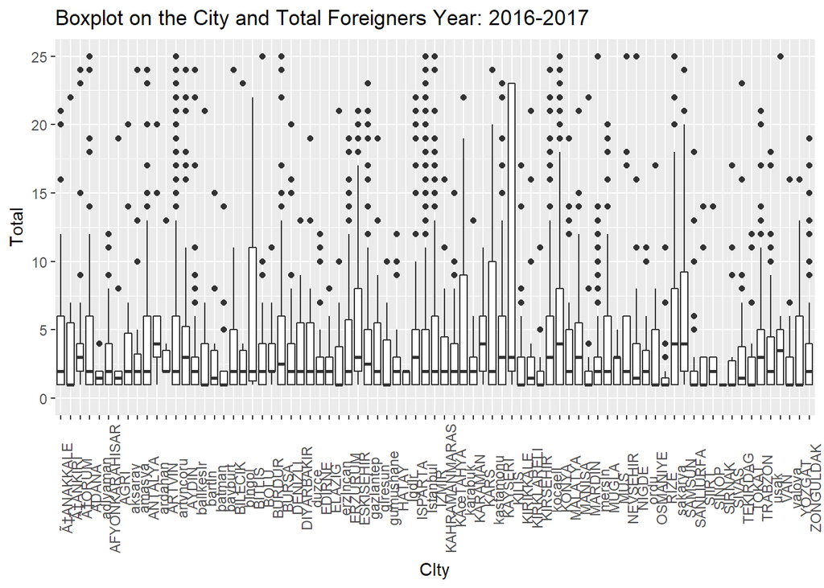

```r
qplot(x = CIty , y = Total , data = f1617Totaless,
  geom = 'boxplot' , main = 'Boxplot on the City and Total Foreigners Year: 2016-2017')+
  scale_y_continuous(limits = c(0,25))+
  theme(axis.text.x = element_text(angle = 90))
```

# Univariate Analysis

### What is the structure of your dataset?

It shows the distribution and variation of foreign university students in Turkey

### What is/are the main feature(s) of interest in your dataset?

Nationality - Countries where the students come from Universities - in which they study Total - Total number of students based in the above mentioned features

### What other features in the dataset do you think will help support your investigation into your feature(s) of interest?

Cities - where they study The type of universities they choose: whether government, private or other Time(In years) over which these students move to Turkey

### Did you create any new variables from existing variables in the dataset?

Ofcourse

### Of the features you investigated, were there any unusual distributions? Did you perform any operations on the data to tidy, adjust, or change the form of the data? If so, why did you do this?

Yes I did. To standardise the data for easier inverstigation and generalisation of results The original data had a lot of inconsistencies in many areas such as names

# Bivariate Plots Section

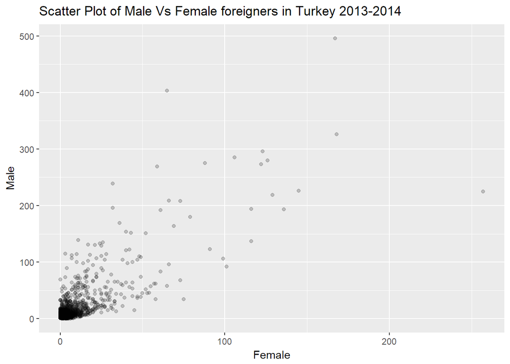

### Total Students in Cities 2013-2014

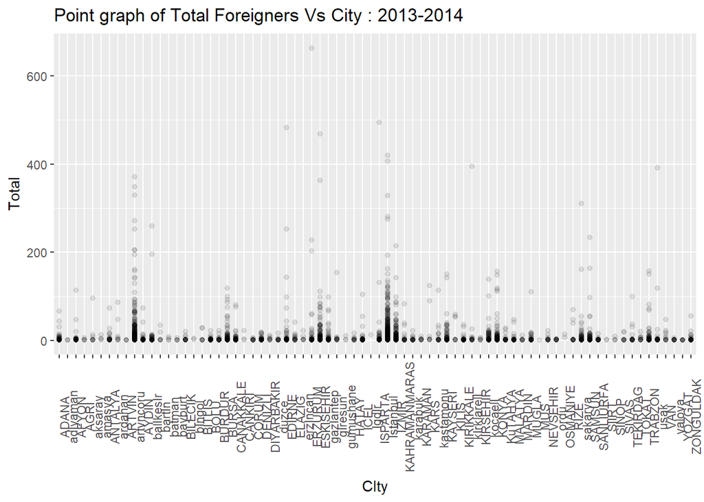

```r
ggplot(aes(x = CIty, y = Total), data = f1314Totaless) +
  geom_point(alpha = 1/10) +
  ggtitle( "Point graph of Total Foreigners Vs City : 2013-2014") +
  theme(axis.text.x = element_text(angle = 90))
```

# Comparisons

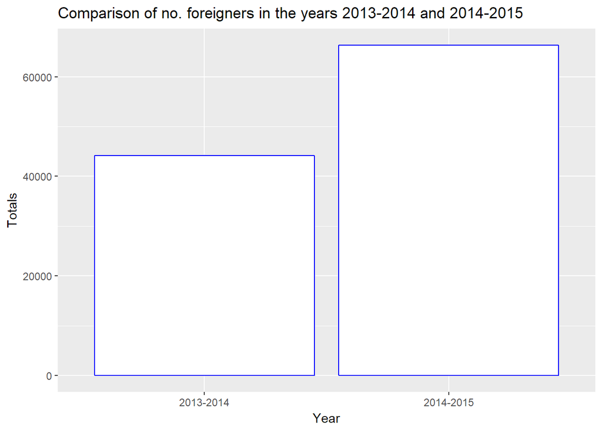

```r
total1314 <- max(foreign1314$Total)
total1415 <- max(foreign1415$Total)
totalf <- data.frame(Year=c("2013-2014", "2014-2015"),
                Totals=c(total1314, total1415))
ggplot(data=totalf, aes(x=Year, y=Totals)) +
  geom_bar(stat="identity", color="blue", fill="white")+
  ggtitle( "Comparison of no. foreigners in the years 2013-2014 and 2014-2015")
```

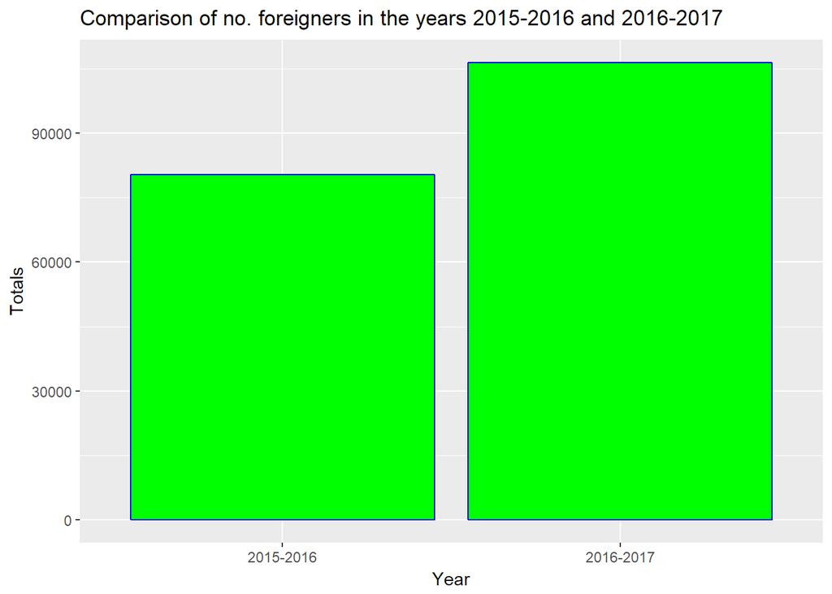

```r
total1516 <- max(foreign1516$Total)
total1617 <- max(foreign1617$Total)
totalf <- data.frame(Year=c("2015-2016", "2016-2017"),
                Totals=c(total1516, total1617))
ggplot(data=totalf, aes(x=Year, y=Totals)) +
  geom_bar(stat="identity", color="blue", fill="green")+
  ggtitle( "Comparison of no. foreigners in the years 2015-2016 and 2016-2017")
```

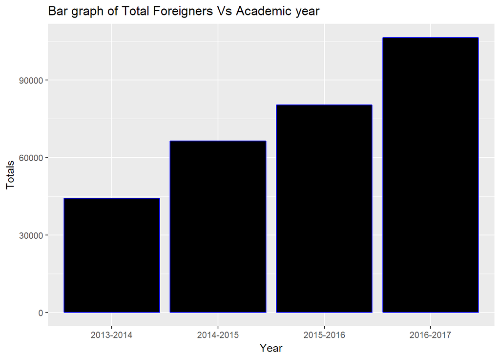

```r
total1314 <- max(foreign1314$Total)
total1415 <- max(foreign1415$Total)
totalf <- data.frame(Year=c("2013-2014", "2014-2015", "2015-2016", "2016-2017"),
                Totals=c(total1314, total1415, total1516, total1617))
ggplot(data=totalf, aes(x=Year, y=Totals)) +
  geom_bar(stat="identity", color="blue", fill="black")+
  ggtitle( "Bar graph of Total Foreigners Vs Academic year")
```

# Bivariate Analysis

### Talk about some of the relationships you observed in this part of the investigation. How did the feature(s) of interest vary with other features in the dataset?

More foreigners come to Turkey for education over time. The number of foreigners is steadily increasing

### What was the strongest relationship you found?

The increasing number of foreingers over time

# Multivariate Plots Section

```
## No summary function supplied, defaulting to `mean_se()
```

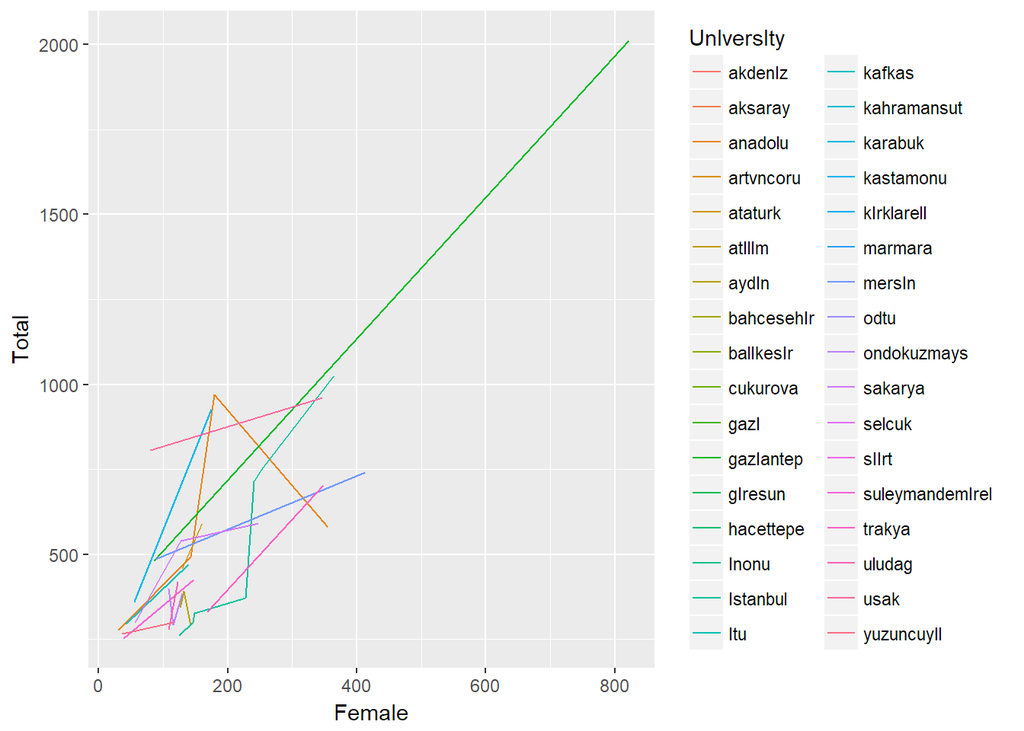

```r
library(ggplot2)
ggplot(aes(x=Female, y=Total),
    data = subset(f1617Totaless, (f1617Totaless$Total>250) )) +
    geom_line(aes(color = UnIversIty), stat = 'summary')
```

```
## No summary function supplied, defaulting to `mean_se()
```

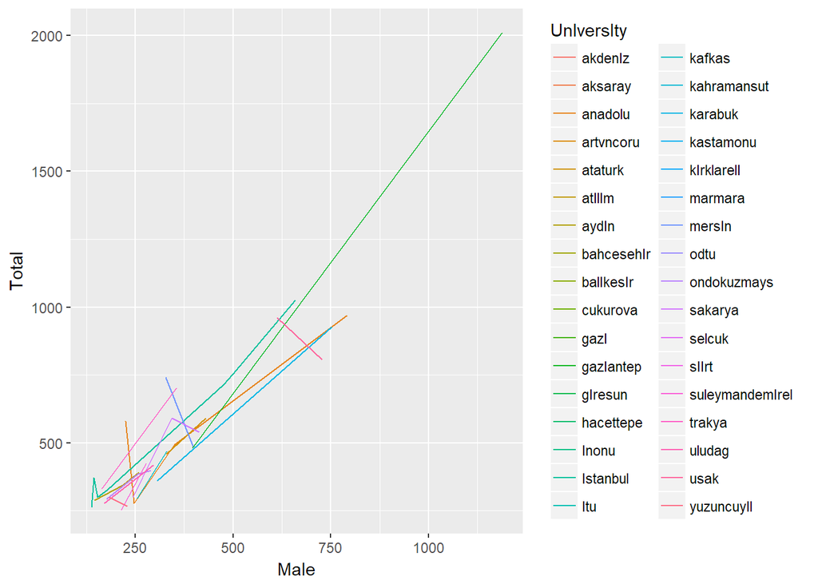

```r
library(ggplot2)
ggplot(aes(x=Male, y=Total),
  data = subset(f1617Totaless, (f1617Totaless$Total>250) )) +
  geom_line(aes(color = UnIversIty), stat = 'summary')
```

## Universities with more than 50 foreign students in Istanbul + Their average number of foreign students | 2013-2014

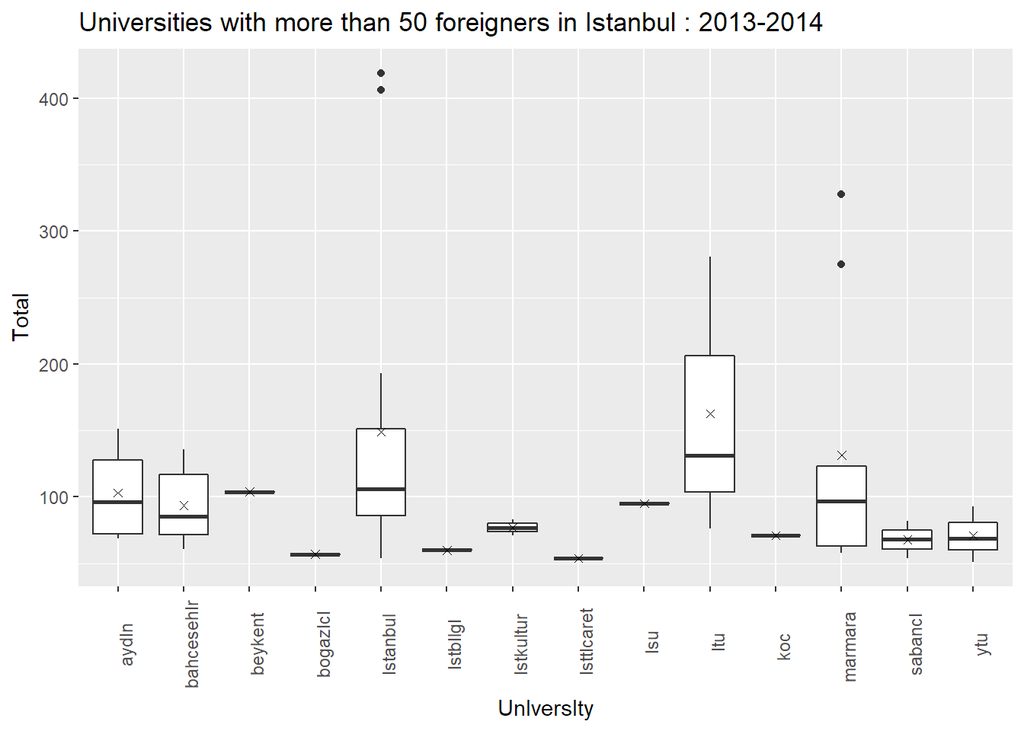

```r
library(ggplot2)
ggplot(aes(x=UnIversIty, y=Total),
       data = subset(f1314Totaless, (f1314Totaless$CIty=="Istanbul")&(f1314Totaless$Total>50) )) +
  geom_boxplot() +
  stat_summary(fun.y = mean, geom = 'point', shape = 4)+
  theme(axis.text.x = element_text(angle = 90))+
  ggtitle( "Universities with more than 50 foreigners in Istanbul : 2013-2014")
```

### Total variables

```r
# 2013 - 2014
totalAll1314 = foreign1314$Total


# 2014 - 2015
totalAll1415 = foreign1415$Total

# 2015 - 2016
totalAll1516 = foreign1516$Total

# 2016 - 2017
totalAll1617 = foreign1617$Total

totalsList = list(totalAll1314, totalAll1415, totalAll1516, totalAll1617)
totalsnames = c("2013-2014", "2014-2015","2015-2016", "2016-2017")
names(totalsList) = totalsnames

summary(totalsList)
```

```
##           Length Class  Mode
## 2013-2014 4146   -none- numeric
## 2014-2015 5153   -none- numeric
## 2015-2016 5865   -none- numeric
## 2016-2017 7258   -none- numeric
```

#### Scaling the totals

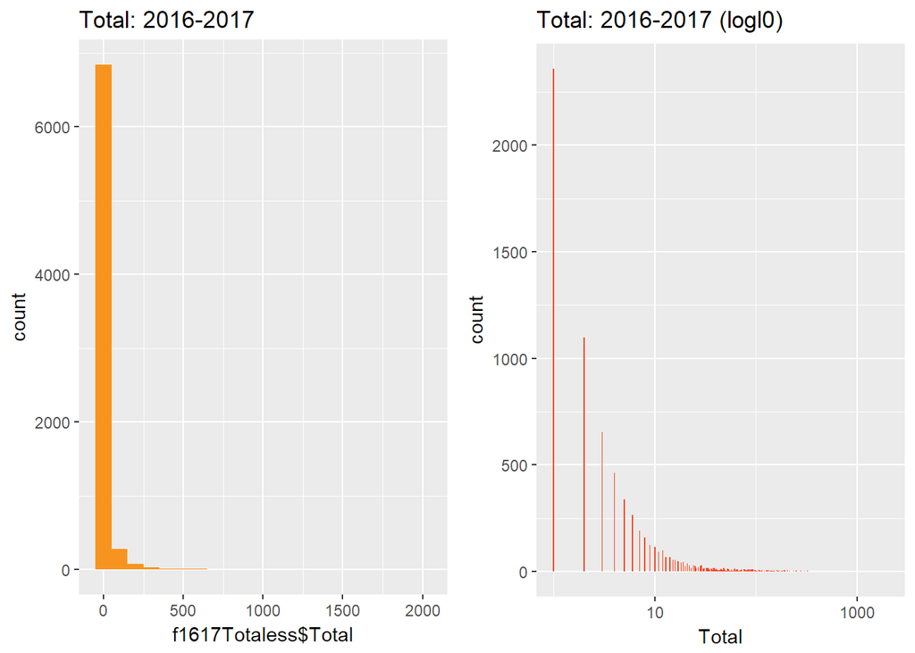

```r
library(ggplot2)
library(gridExtra)
p1 <- qplot(data = f1617Totaless, x = f1617Totaless$Total, binwidth = 100, fill = I ('#F79420')) +
        ggtitle("Total: 2016-2017")
p2 <- qplot(data = f1617Totaless, x = Total, binwidth = 0.01, fill = I ('#F74420')) +
        ggtitle("Total: 2016-2017 (logl0)") + scale_x_log10()
grid.arrange(p1, p2, ncol = 2)
```

## Universities with more than 100 foreign students in Istanbul + Their average number of foreign students 2013-2014

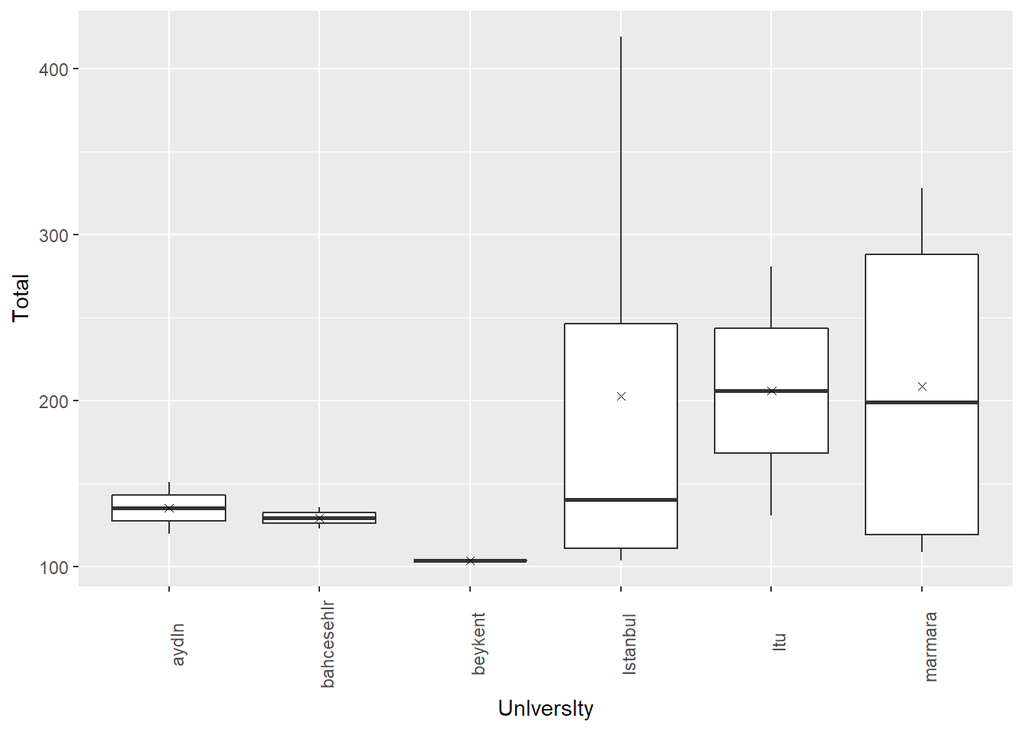

```r
library(ggplot2)
ggplot(aes(x=UnIversIty, y=Total),
       data = subset(f1314Totaless, (f1314Totaless$CIty=="Istanbul")&(f1314Totaless$Total>100) )) +
  geom_boxplot() +
  stat_summary(fun.y = mean, geom = 'point', shape = 4)+
  theme(axis.text.x = element_text(angle = 90))
```

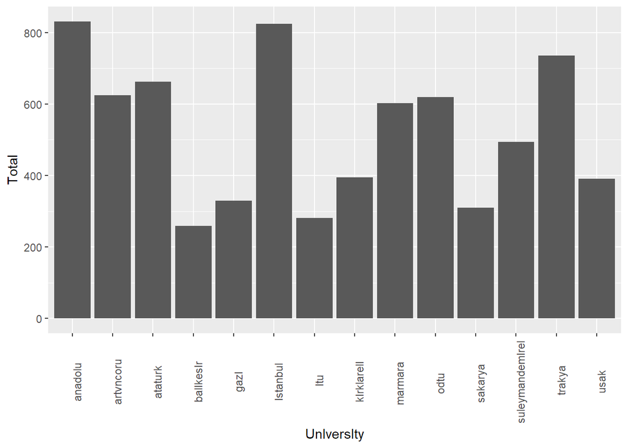

```r
library(ggplot2)
ggplot(aes(x=UnIversIty, y=Total),
       data = subset(f1314Totaless, (f1314Totaless$Total>250) )) +
  geom_histogram(stat = 'identity') +
  theme(axis.text.x = element_text(angle = 90))
```

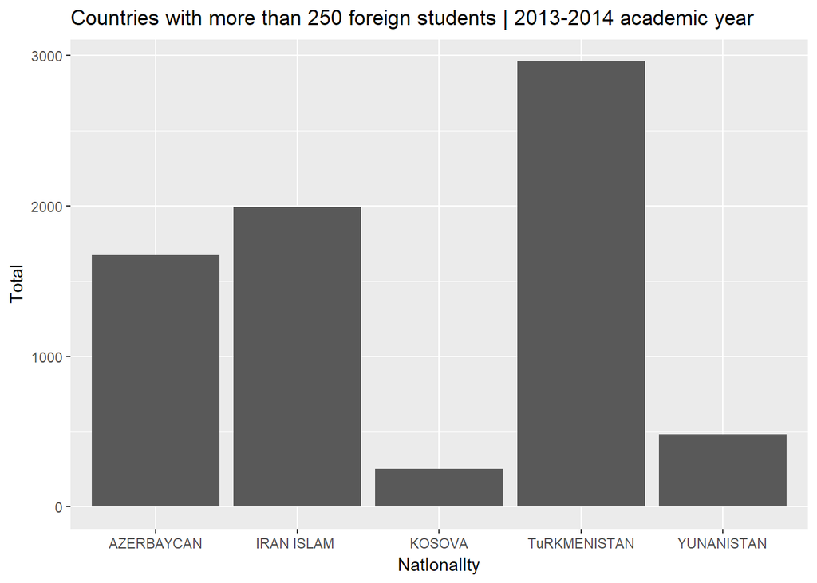

```r
library(ggplot2)
ggplot(aes(x=NatIonalIty, y=Total),
       data = subset(f1314Totaless, (f1314Totaless$Total>250) )) +
  geom_histogram(stat = 'identity') +
  ggtitle("Countries with more than 250 foreign students | 2013-2014 academic year")
```

## Countries with Most Students

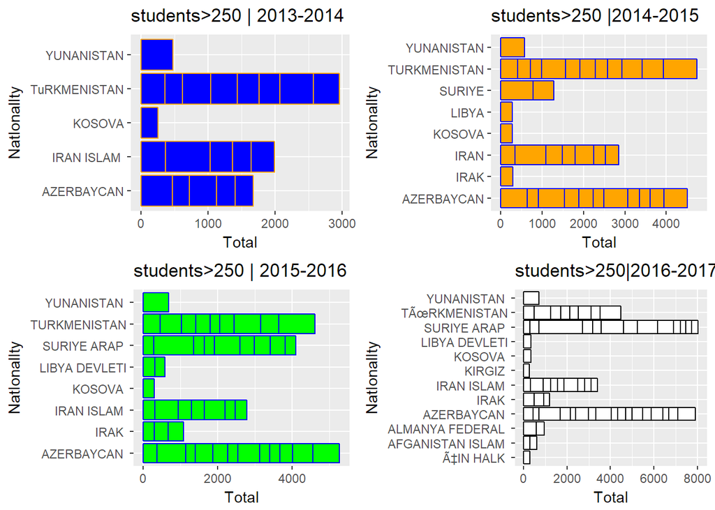

```r
p1 = ggplot(aes(x=NatIonalIty, y=Total),
       data = subset(f1314Totaless, (f1314Totaless$Total>250) )) +
  geom_histogram(stat = 'identity', color="orange", fill="blue") +
  coord_flip() +
  ggtitle("students>250 | 2013-2014")
p2 = ggplot(aes(x=NatIonalIty, y=Total),
       data = subset(f1415Totaless, (f1415Totaless$Total>250) )) +
  geom_histogram(stat = 'identity', color="blue", fill="orange") +
  coord_flip()+
  ggtitle("students>250 |2014-2015")
p3 = ggplot(aes(x=NatIonalIty, y=Total),
       data = subset(f1516Totaless, (f1516Totaless$Total>250) )) +
  geom_histogram(stat = 'identity', color="blue", fill="green") +
  coord_flip() + #theme(axis.text.x = element_text(angle = 90))+
  ggtitle("students>250 | 2015-2016")
p4 = ggplot(aes(x=NatIonalIty, y=Total),
       data = subset(f1617Totaless, (f1617Totaless$Total>250) )) +
  geom_histogram(stat = 'identity', color="black", fill="white") +
  coord_flip() +
  ggtitle("students>250|2016-2017")
library(gridExtra)
grid.arrange(p1, p2, p3, p4, nrow = 2)
```

## Universities with Most Students

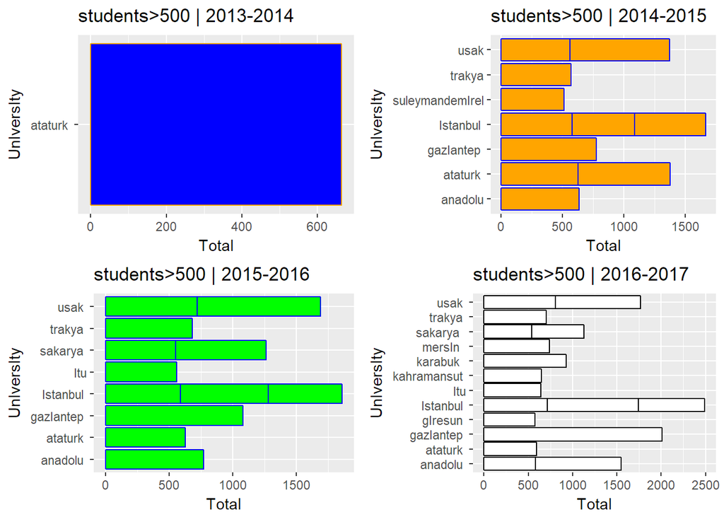

```r
p1 = ggplot(aes(x=UnIversIty, y=Total),
       data = subset(f1314Totaless, (f1314Totaless$Total>500) )) +
  geom_histogram(stat = 'identity', color="orange", fill="blue") +
  coord_flip() +
  ggtitle("students>500 | 2013-2014")
p2 = ggplot(aes(x=UnIversIty, y=Total),
       data = subset(f1415Totaless, (f1415Totaless$Total>500) )) +
  geom_histogram(stat = 'identity', color="blue", fill="orange") +
  coord_flip()+
  ggtitle("students>500 | 2014-2015")
p3 = ggplot(aes(x=UnIversIty, y=Total),
       data = subset(f1516Totaless, (f1516Totaless$Total>500) )) +
  geom_histogram(stat = 'identity', color="blue", fill="green") +
  coord_flip() + #theme(axis.text.x = element_text(angle = 90))+
  ggtitle("students>500 | 2015-2016")
p4 = ggplot(aes(x=UnIversIty, y=Total),
       data = subset(f1617Totaless, (f1617Totaless$Total>500) )) +
  geom_histogram(stat = 'identity', color="black", fill="white") +
  coord_flip() +
  ggtitle("students>500 | 2016-2017")
library(gridExtra)
grid.arrange(p1, p2, p3, p4, nrow = 2)
```

# Relationships between main features

```r
library(GGally)
library(scales)
```

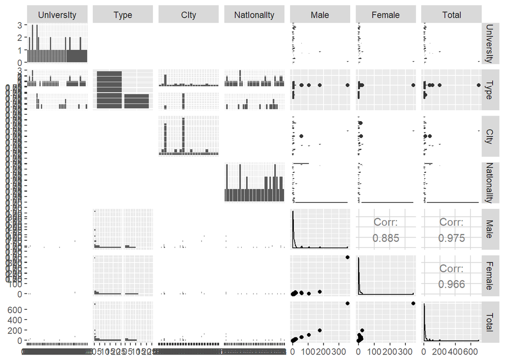

```r
set.seed(20022012)
foreignerSample <- f1617Totaless[sample(1:length(f1617Totaless$Total), 50), ]
ggpairs(foreignerSample, cardinality_threshold = 192, wrap = c(shape = I('.'), outlier.shape = I('.')))
```

# Ratio Plots

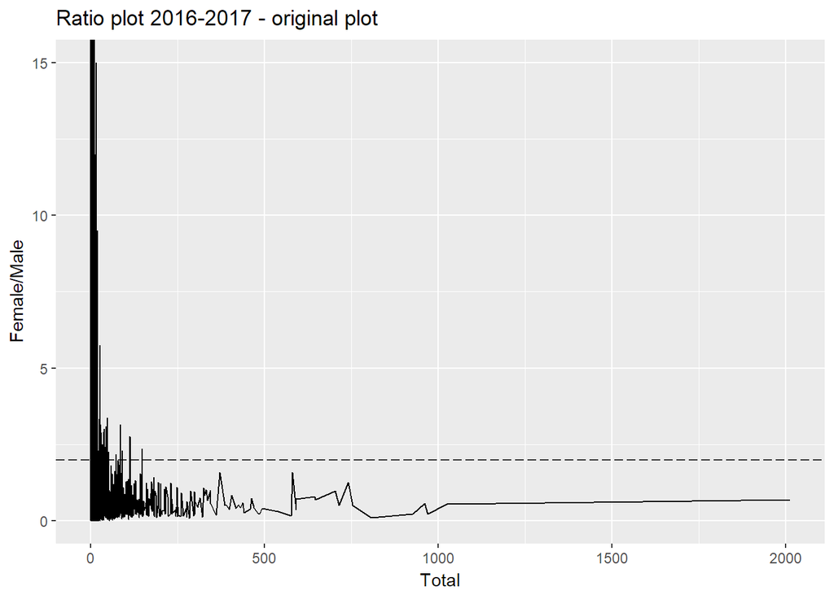

```r
ggplot(data = f1617Totaless, aes(x = Total, y = Female / Male)) +
  geom_line() +
  geom_hline(yintercept = 2, alpha = 0.8, linetype = 5) +
  ggtitle("Ratio plot 2016-2017 - original plot")
```

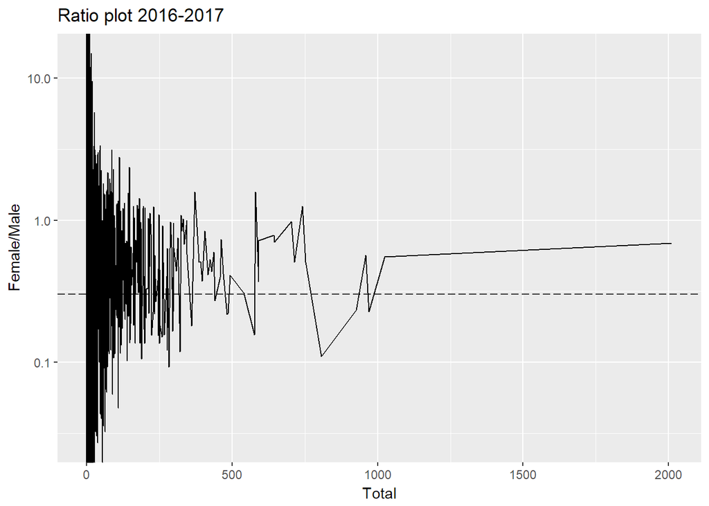

```r
ggplot(data = f1617Totaless, aes(x = Total, y = Female / Male)) +
  geom_line() +
  scale_y_log10() +
  geom_hline(yintercept = 0.3, alpha = 0.8, linetype = 5) +
  ggtitle("Ratio plot 2016-2017")
```